# Part A

DOMAIN: Botanical Research

CONTEXT: University X is currently undergoing some research involving understanding the characteristics of plant and plant seedlings at various stages of growth. They already have have invested on curating sample images. They require an automation which can create a classifier capable of determining a plant's species from a photo.

DATA DESCRIPTION: The dataset comprises of images from 12 plant species. Source: https://www.kaggle.com/c/plant-seedlings-classification/data.

PROJECT OBJECTIVE: To create a classifier capable of determining a plant's species from a photo.

## Steps and tasks:

## 1. Import and Understand the data

```python
from glob import glob
import cv2
import numpy as np
import pandas as pd
from tqdm import tqdm
from matplotlib import pyplot as plt
import random
from tensorflow.keras.models import Sequential
from tensorflow.keras.layers import Dense, Dropout, Flatten, Conv2D, MaxPool2D,Activation,GlobalMaxPool2D,GlobalAveragePooling2D
from tensorflow.keras.layers import BatchNormalization
from tensorflow.keras.optimizers import Adam,RMSprop

from tensorflow.keras.preprocessing.image import ImageDataGenerator

from sklearn import preprocessing
from sklearn.model_selection import train_test_split
from sklearn.metrics import confusion_matrix,classification_report,accuracy_score
```

```python
from tensorflow.keras import losses
from tensorflow.keras import optimizers
```

### A. Extract ‘plant-seedlings-classification.zip’ into new folder (unzipped) using python.

```python
path = "plant-seedlings-classification.zip"

from zipfile import ZipFile
with ZipFile(path, 'r') as zip:
  zip.extractall('./Traindata')
```

### B. Map the images from train folder with train labels to form a DataFrame

```python
imgpath = "./Traindata/plant-seedlings-classification/train/*/*.png"
files = glob(imgpath)

Image = []
Label = []  # species
name =[]
j = 1
num = len(files)

# Obtain images  obtain labels
for img in tqdm(files):
    Image.append(cv2.imread(img))  #image

    Label.append(img.split('\\')[-2]) #species
    name.append(img.split('\\')[-1])# Get image name
```

```python
data = pd.DataFrame( {'Imagename': name,'Label': Label,'Actualimage': Image})
```

```python
data.shape
```

```
(4750, 3)
```

```python
data.head()
```

|  | Imagename | Label | Actualimage |
| --- | --- | --- | --- |
| 0 | 0050f38b3.png | Black-grass | [[[27, 50, 80], [18, 42, 71], [36, 57, 83], [4... |
| 1 | 0183fdf68.png | Black-grass | [[[37, 43, 55], [37, 43, 54], [40, 46, 57], [4... |
| 2 | 0260cffa8.png | Black-grass | [[[24, 32, 45], [21, 30, 44], [22, 30, 45], [2... |
| 3 | 05eedce4d.png | Black-grass | [[[51, 84, 108], [56, 89, 112], [54, 88, 110],... |
| 4 | 075d004bc.png | Black-grass | [[[165, 162, 162], [165, 161, 163], [160, 157,... |

### C. Write a function that will select n random images and display images along with its species.

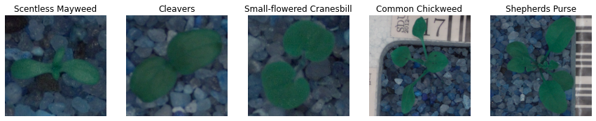

```python
def displayimage(n):
    plt.figure(figsize = (15, 4.5))
    for i in range(n):

        plt.subplot(1, n, i+1)
        index=random.randint(0, 4750)
        plt.imshow(Image[index])
        plt.title(Label[index])
        plt.axis('off')
    plt.show()
n=5
displayimage(n)
```

## 2. Data preprocessing

### A. Create X & Y from the DataFrame.

```python
y=data['Label']
x=data['Actualimage']
```

### B. Encode labels of the images.

```python
from tensorflow.keras.utils import to_categorical
```

```python
le = preprocessing.LabelEncoder()
le.fit(y)
print('Classes'+str(le.classes_))
encodedlabel = le.transform(y)
convertedlabels = to_categorical(encodedlabel)
classes = convertedlabels.shape[1]
print(str(classes))
```

```
Classes['Black-grass' 'Charlock' 'Cleavers' 'Common Chickweed' 'Common wheat'
 'Fat Hen' 'Loose Silky-bent' 'Maize' 'Scentless Mayweed'
 'Shepherds Purse' 'Small-flowered Cranesbill' 'Sugar beet']
12
```

```python
convertedlabels.shape
```

```
(4750, 12)
```

### C. Unify shape of all the images.

```python
unifyx=[]
for i in x:
    unifyx.append(cv2.resize(i,(128, 128)))
```

```python
unifyx=np.asarray(unifyx)
unifyx.shape
```

```
(4750, 128, 128, 3)
```

### D. Normalise all the images.

```python
x_norm=(unifyx/255)
```

```python
x_norm.shape
```

```
(4750, 128, 128, 3)
```

# 3. Model training

### A. Split the data into train and test data.

```python
X_train,X_test,y_train,y_test = train_test_split(x_norm,convertedlabels,test_size=0.3,random_state=38,stratify=convertedlabels)
```

```python
convertedlabels.shape
```

```
(4750, 12)
```

### B. Create new CNN architecture to train the model.

```python
model = Sequential()

model.add(Conv2D(filters=64, kernel_size=(3, 3), input_shape=(128, 128, 3), activation='relu'))
model.add(MaxPool2D((2, 2)))
model.add(Dropout(0.25))

model.add(Conv2D(filters=128, kernel_size=(3, 3), activation='relu'))
model.add(MaxPool2D((2, 2)))
model.add(Dropout(0.25))

model.add(Flatten())

model.add(Dense(128, activation='relu'))
model.add(Dropout(0.25))

model.add(Dense(64, activation='relu'))
model.add(Dropout(0.25))

model.add(Dense(classes, activation='softmax'))
model.compile(loss='categorical_crossentropy', optimizer='adam', metrics=['accuracy'])

model.summary()
```

```
Model: "sequential"
_________________________________________________________________
Layer (type)                 Output Shape              Param #
=================================================================
conv2d (Conv2D)              (None, 126, 126, 64)      1792
_________________________________________________________________
max_pooling2d (MaxPooling2D) (None, 63, 63, 64)        0
_________________________________________________________________
dropout (Dropout)            (None, 63, 63, 64)        0
_________________________________________________________________
conv2d_1 (Conv2D)            (None, 61, 61, 128)       73856
_________________________________________________________________
max_pooling2d_1 (MaxPooling2 (None, 30, 30, 128)       0
_________________________________________________________________
dropout_1 (Dropout)          (None, 30, 30, 128)       0
_________________________________________________________________
flatten (Flatten)            (None, 115200)            0
_________________________________________________________________
dense (Dense)                (None, 128)               14745728
_________________________________________________________________
dropout_2 (Dropout)          (None, 128)               0
_________________________________________________________________
dense_1 (Dense)              (None, 64)                8256
_________________________________________________________________
dropout_3 (Dropout)          (None, 64)                0
_________________________________________________________________
dense_2 (Dense)              (None, 12)                780
=================================================================
Total params: 14,830,412
Trainable params: 14,830,412
Non-trainable params: 0
_________________________________________________________________
```

### C. Train the model on train data and validate on test data.

# DATA AUGMENTATION

```python
generator = ImageDataGenerator(rotation_range = 180,
                               zoom_range = 0.2,
                               width_shift_range = 0.2,
                               height_shift_range = 0.2,
                               horizontal_flip = True,
                               vertical_flip = True)
generator.fit(X_train)
```

```python
history = model.fit(generator.flow(X_train,y_train,batch_size=64),epochs=30, verbose=2,shuffle=True,validation_data=(X_test,y_test))
pd.DataFrame(history.history)
```

```
52/52 - 179s - loss: 2.6209 - accuracy: 0.0944 - val_loss: 2.4454 - val_accuracy: 0.1375
52/52 - 252s - loss: 2.4419 - accuracy: 0.1296 - val_loss: 2.4175 - val_accuracy: 0.1375
52/52 - 237s - loss: 2.4203 - accuracy: 0.1459 - val_loss: 2.3693 - val_accuracy: 0.1495
52/52 - 218s - loss: 2.2449 - accuracy: 0.2262 - val_loss: 1.9793 - val_accuracy: 0.2688
52/52 - 203s - loss: 2.0620 - accuracy: 0.2547 - val_loss: 1.8582 - val_accuracy: 0.2968
52/52 - 198s - loss: 1.9950 - accuracy: 0.2695 - val_loss: 1.9249 - val_accuracy: 0.3432
52/52 - 215s - loss: 1.9440 - accuracy: 0.2917 - val_loss: 1.7708 - val_accuracy: 0.3874
52/52 - 213s - loss: 1.9303 - accuracy: 0.3017 - val_loss: 1.8041 - val_accuracy: 0.3705
52/52 - 194s - loss: 1.8975 - accuracy: 0.3083 - val_loss: 1.7035 - val_accuracy: 0.4204
52/52 - 200s - loss: 1.8767 - accuracy: 0.3296 - val_loss: 1.6701 - val_accuracy: 0.4161
52/52 - 222s - loss: 1.8248 - accuracy: 0.3534 - val_loss: 1.7217 - val_accuracy: 0.3965
52/52 - 235s - loss: 1.8053 - accuracy: 0.3597 - val_loss: 1.5610 - val_accuracy: 0.5053
52/52 - 224s - loss: 1.7294 - accuracy: 0.3988 - val_loss: 1.5103 - val_accuracy: 0.4856
52/52 - 234s - loss: 1.6929 - accuracy: 0.4009 - val_loss: 1.4672 - val_accuracy: 0.5361
52/52 - 226s - loss: 1.6646 - accuracy: 0.4171 - val_loss: 1.4783 - val_accuracy: 0.5109
52/52 - 221s - loss: 1.6529 - accuracy: 0.4039 - val_loss: 1.5008 - val_accuracy: 0.4989
52/52 - 210s - loss: 1.6098 - accuracy: 0.4316 - val_loss: 1.3530 - val_accuracy: 0.5551
52/52 - 210s - loss: 1.5964 - accuracy: 0.4433 - val_loss: 1.3556 - val_accuracy: 0.5579
52/52 - 208s - loss: 1.5537 - accuracy: 0.4436 - val_loss: 1.4255 - val_accuracy: 0.4954
52/52 - 211s - loss: 1.5742 - accuracy: 0.4523 - val_loss: 1.3166 - val_accuracy: 0.5572
52/52 - 207s - loss: 1.5642 - accuracy: 0.4505 - val_loss: 1.3426 - val_accuracy: 0.5663
52/52 - 212s - loss: 1.5308 - accuracy: 0.4617 - val_loss: 1.3007 - val_accuracy: 0.5705
52/52 - 217s - loss: 1.5409 - accuracy: 0.4626 - val_loss: 1.2894 - val_accuracy: 0.5839
52/52 - 212s - loss: 1.5181 - accuracy: 0.4746 - val_loss: 1.2649 - val_accuracy: 0.6098
52/52 - 227s - loss: 1.5097 - accuracy: 0.4716 - val_loss: 1.2688 - val_accuracy: 0.5811
52/52 - 216s - loss: 1.5006 - accuracy: 0.4710 - val_loss: 1.2523 - val_accuracy: 0.5874
52/52 - 218s - loss: 1.4873 - accuracy: 0.4713 - val_loss: 1.3378 - val_accuracy: 0.5326
52/52 - 209s - loss: 1.5062 - accuracy: 0.4614 - val_loss: 1.3527 - val_accuracy: 0.5389
52/52 - 208s - loss: 1.4550 - accuracy: 0.4854 - val_loss: 1.2471 - val_accuracy: 0.5937
52/52 - 211s - loss: 1.4675 - accuracy: 0.4851 - val_loss: 1.3524 - val_accuracy: 0.5214
```

|  | loss | accuracy | val_loss | val_accuracy |
| --- | --- | --- | --- | --- |
| 0 | 2.620875 | 0.094436 | 2.445359 | 0.137544 |
| 1 | 2.441868 | 0.129624 | 2.417467 | 0.137544 |
| 2 | 2.420268 | 0.145865 | 2.369287 | 0.149474 |
| 3 | 2.244933 | 0.226165 | 1.979264 | 0.268772 |
| 4 | 2.061985 | 0.254737 | 1.858151 | 0.296842 |
| 5 | 1.994951 | 0.269474 | 1.924903 | 0.343158 |
| 6 | 1.943974 | 0.291729 | 1.770814 | 0.387368 |
| 7 | 1.930273 | 0.301654 | 1.804117 | 0.370526 |
| 8 | 1.897541 | 0.308271 | 1.703530 | 0.420351 |
| 9 | 1.876667 | 0.329624 | 1.670072 | 0.416140 |
| 10 | 1.824796 | 0.353383 | 1.721732 | 0.396491 |
| 11 | 1.805254 | 0.359699 | 1.560964 | 0.505263 |
| 12 | 1.729386 | 0.398797 | 1.510311 | 0.485614 |
| 13 | 1.692939 | 0.400902 | 1.467165 | 0.536140 |
| 14 | 1.664627 | 0.417143 | 1.478298 | 0.510877 |
| 15 | 1.652912 | 0.403910 | 1.500756 | 0.498947 |
| 16 | 1.609764 | 0.431579 | 1.353038 | 0.555088 |
| 17 | 1.596419 | 0.443308 | 1.355639 | 0.557895 |
| 18 | 1.553736 | 0.443609 | 1.425451 | 0.495439 |
| 19 | 1.574211 | 0.452331 | 1.316591 | 0.557193 |
| 20 | 1.564238 | 0.450526 | 1.342597 | 0.566316 |
| 21 | 1.530786 | 0.461654 | 1.300714 | 0.570526 |
| 22 | 1.540854 | 0.462556 | 1.289415 | 0.583860 |
| 23 | 1.518072 | 0.474586 | 1.264865 | 0.609825 |
| 24 | 1.509735 | 0.471579 | 1.268824 | 0.581053 |
| 25 | 1.500620 | 0.470977 | 1.252295 | 0.587368 |
| 26 | 1.487309 | 0.471278 | 1.337849 | 0.532632 |
| 27 | 1.506200 | 0.461353 | 1.352651 | 0.538947 |
| 28 | 1.454977 | 0.485414 | 1.247148 | 0.593684 |
| 29 | 1.467474 | 0.485113 | 1.352428 | 0.521403 |

```
Testing the model on validation set dataset
Classification Report
--------------------------------------------------------------------------------
              precision    recall  f1-score   support

           0       0.00      0.00      0.00        79
           1       0.41      0.95      0.58       117
           2       0.52      0.38      0.44        86
           3       0.75      0.87      0.81       183
           4       0.67      0.06      0.11        66
           5       0.51      0.27      0.35       143
           6       0.59      0.86      0.70       196
           7       0.43      0.30      0.36        66
           8       0.51      0.41      0.45       155
           9       0.38      0.09      0.14        69
          10       0.48      0.79      0.60       149
          11       0.28      0.21      0.24       116

    accuracy                           0.52      1425
   macro avg       0.46      0.43      0.40      1425
weighted avg       0.49      0.52      0.47      1425
```

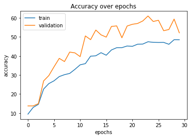

```python
plt.plot(np.array(history.history['accuracy']) * 100)
plt.plot(np.array(history.history['val_accuracy']) * 100)
plt.ylabel('accuracy')
plt.xlabel('epochs')
print('Testing the model on validation set dataset')
predictions = np.argmax(model.predict(X_test), axis=-1)
rounded_y=np.argmax(y_test, axis=1)
print('Classification Report'); print('--'*40)
print(classification_report(rounded_y,predictions))
plt.legend(['train', 'validation'])
plt.title('Accuracy over epochs')
plt.show()
```

### D. Select a random image and print actual label and predicted label for the same

```
Was predicted  6 Loose Silky-bent
Was labeled  6 Loose Silky-bent
Predicted Probabilities:  [[2.8724471e-01 4.7017020e-05 1.9333222e-03 6.5631722e-04 1.5251996e-01
  4.8886705e-02 4.9597496e-01 1.7877708e-03 8.5524721e-03 1.1131757e-04
  4.1249298e-04 1.8730853e-03]]
```

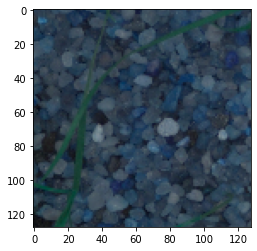

```python
image_index = 32
plt.imshow(X_test[image_index])
pred = model.predict(np.reshape(X_test[image_index],[1,128,128,3]))
print("Was predicted ",pred.argmax(), str(le.classes_[pred.argmax()]))
print("Was labeled ",rounded_y[image_index],str(le.classes_[rounded_y[image_index]]))
print("Predicted Probabilities: ",pred)
```

# PART-B

DOMAIN: Botanical Research

CONTEXT: University X is currently undergoing some research involving understanding the characteristics of flowers. They already have have invested on curating sample images. They require an automation which can create a classifier capable of determining a flower’s species from a photo.

DATA DESCRIPTION: The dataset comprises of images from 17 plant species.

PROJECT OBJECTIVE: To experiment with various approaches to train an image classifier to predict type of flower from the image.

## Steps and tasks:

## 1. Import and Understand the data

### A. Import and read oxflower17 dataset from tflearn and split into X and Y while loading.

```python
import tflearn
import tflearn.datasets.oxflower17 as oxflower17
X, y = oxflower17.load_data(resize_pics=(224,224))
```

[output not shown]

```python
y
```

```
array([4, 7, 5, ..., 2, 7, 8])
```

### B. Print Number of images and shape of the images

```python
print("Number of images",X.shape[0])
print("Shape of the images", X.shape[1:])
X.shape
```

```
Number of images 1360
Shape of the images (224, 224, 3)
```

```
(1360, 224, 224, 3)
```

### C. Print count of each class from y.

```python
print("Value count of class from Y\n\n",pd.Series(y).value_counts())
```

```
Value count of class from Y

 4     80
12    80
11    80
0     80
8     80
10    80
16    80
1     80
2     80
7     80
13    80
3     80
15    80
6     80
14    80
5     80
9     80
dtype: int64
```

## 2. Image Exploration & Transformation

### A. Display 5 random images.

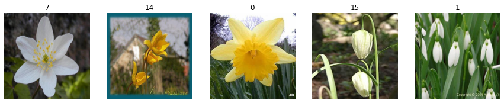

```python
def displayimage(n):
    plt.figure(figsize = (15, 4.5))
    for i in range(n):

        plt.subplot(1, n, i+1)
        index=random.randint(0, 1360)
        plt.imshow(X[index])
        plt.title(y[index])
        plt.axis('off')
    plt.show()
n=5
displayimage(n)
```

### B. Select any image from the dataset and assign it to a variable.

```python
flowerimg=random.choice(X)
```

```
(-0.5, 223.5, 223.5, -0.5)
```

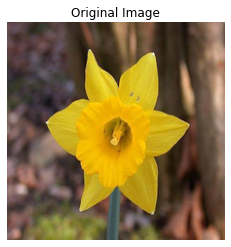

```python
plt.imshow(flowerimg)
plt.title('Original Image')
plt.axis('off')
```

### C. Transform the image into grayscale format and display the same.

```python
def gray_image(image):
    img_gray = cv2.cvtColor(image,cv2.COLOR_BGR2GRAY)
    return img_gray
grayflowerimg=gray_image(flowerimg)
```

```
(-0.5, 223.5, 223.5, -0.5)
```

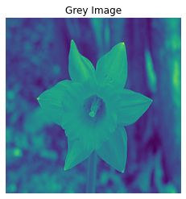

```python
plt.imshow(grayflowerimg)
plt.title('Grey Image')
plt.axis('off')
```

### D. Apply a filter to sharpen the image and display the image before and after sharpening

```python
def sharpen_image(image):
    sharp_filter=np.array([[0,-1,0],[-1,5,-1],[0,-1,0]])
    image_sharp = cv2.filter2D(image,kernel=sharp_filter,ddepth=-1)
    return image_sharp
sharpflowerimg=sharpen_image(flowerimg)
```

```
Clipping input data to the valid range for imshow with RGB data ([0..1] for floats or [0..255] for integers).
```

```
(-0.5, 223.5, 223.5, -0.5)
```

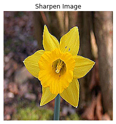

```python
plt.imshow(sharpflowerimg)
plt.title('Sharpen Image')
plt.axis('off')
```

### E. Apply a filter to blur the image and display the image before and after blur

```
(-0.5, 223.5, 223.5, -0.5)
```

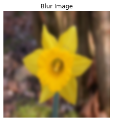

```python
def Blur_image(image):
    image_blurred = cv2.GaussianBlur(image, (0, 0), 3)
    return image_blurred
blurflowerimg=Blur_image(flowerimg)
plt.imshow(blurflowerimg)
plt.title('Blur Image')
plt.axis('off')
```

### F. Display all the 4 images from above questions besides each other to observe the difference.

```
Clipping input data to the valid range for imshow with RGB data ([0..1] for floats or [0..255] for integers).
```

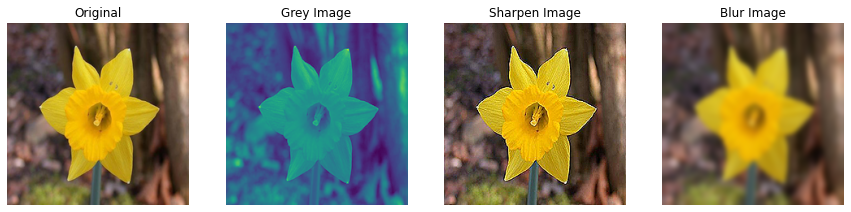

```python
img_title=['Original', 'Grey Image' ,'Sharpen Image','Blur Image']
plt.figure(figsize = (15, 10))
for i,img in enumerate([flowerimg,grayflowerimg,sharpflowerimg,blurflowerimg]):

    plt.subplot(1,4,i+1)
    plt.imshow(img)
    plt.title(img_title[i])
    plt.axis('off')
```

## 3. Model training and Tuning: [

### A. Split the data into train and test with 80:20 proportion.

```python
X=np.array(X)
y=np.array(y)
```

```python
X_train, X_test, y_train, y_test = train_test_split(X, y, test_size=0.2, random_state=50)
```

### B. Train a model using any Supervised Learning algorithm and share performance metrics on test data.

```python
X_train_ML = X_train.astype('float32')
X_train_ML = X_train_ML.reshape(X_train_ML.shape[0], 150528) # 224X224X3 = 150528
X_train_ML = X_train_ML/255

X_test_ML = X_test.astype('float32')
X_test_ML = X_test_ML.reshape(X_test_ML.shape[0], 150528)
X_test_ML = X_test_ML/255


print('Train_Shape:', X_train_ML.shape, y_train.shape)
print('Test_Shape:', X_test_ML.shape, y_test.shape)
```

```
Train_Shape: (1088, 150528) (1088,)
Test_Shape: (272, 150528) (272,)
```

```python
# RANDOM FOREST

# Library
from sklearn.ensemble import RandomForestClassifier
from sklearn.metrics import accuracy_score
# Model
model_RF = RandomForestClassifier(n_estimators=20,
                                    criterion='gini',
                                    max_depth=5)
model_RF.fit(X_train_ML, y_train)

# Accuracy
pred_RF = model_RF.predict(X_test_ML)
RF_Train = model_RF.score(X_train_ML, y_train)
RF_Test = accuracy_score(y_test, pred_RF)

# Output
print("Train Accuracy:",RF_Train)
print("Test Accuracy:",RF_Test)
print(classification_report(y_test,pred_RF))
```

```
Train Accuracy: 0.7702205882352942
Test Accuracy: 0.3897058823529412
              precision    recall  f1-score   support

           0       0.71      0.24      0.36        21
           1       0.38      0.21      0.27        14
           2       0.83      0.59      0.69        17
           3       0.15      0.11      0.13        18
           4       0.44      0.44      0.44        18
           5       0.09      0.15      0.11        13
           6       0.21      0.57      0.31         7
           7       0.27      0.70      0.39        10
           8       0.57      0.47      0.52        17
           9       0.21      0.42      0.28        12
          10       0.67      0.60      0.63        20
          11       0.30      0.47      0.37        15
          12       0.62      0.47      0.53        17
          13       0.40      0.19      0.26        21
          14       0.33      0.08      0.13        12
          15       0.23      0.15      0.18        20
          16       0.61      0.85      0.71        20

    accuracy                           0.39       272
   macro avg       0.41      0.40      0.37       272
weighted avg       0.44      0.39      0.39       272
```

### C. Train a model using Neural Network and share performance metrics on test data.

```python
y_train_NN = pd.get_dummies(y_train)
y_test_NN = pd.get_dummies(y_test)
```

```python
model = Sequential()
model.add(BatchNormalization(input_shape = (150528,)))  ### Batch_Norm Layer

model.add(Dense(256, activation='relu')) ###Multiple Dense units with Relu activation
model.add(Dense(128, activation='relu'))
model.add(Dropout(rate=0.2))
model.add(Dense(64, activation='relu'))
model.add(Dense(64, activation='relu'))
model.add(Dropout(rate=0.2))
model.add(Dense(32, activation='relu'))
model.add(Dense(17, activation='softmax'))

# Compile model
adam = optimizers.Adam(lr=1e-3)
model.compile(loss=losses.categorical_crossentropy, optimizer=adam, metrics=['accuracy']) ### Loss function = Categorical cross entropy

# Fit the model
annhistory = model.fit(X_train_ML, y_train_NN, validation_data=(X_test_ML, y_test_NN), epochs=30, verbose=1)
```

[output not shown]

```
Test loss: 3.27150156918694
Test accuracy: 0.5036765
```

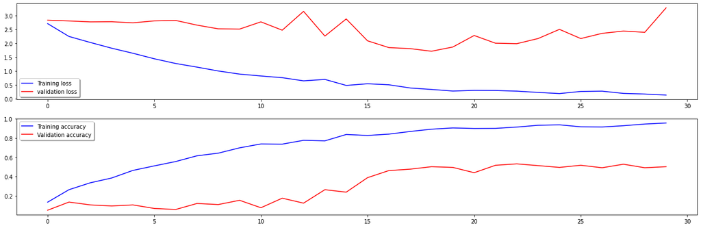

```python
ann_loss, ann_accuracy = model.evaluate(X_test_ML, y_test_NN, verbose=1)
print('Test loss:', ann_loss)
print('Test accuracy:', ann_accuracy)



fig, ax = plt.subplots(2,1 , figsize=(22,7))
ax[0].plot(annhistory.history['loss'], color='b', label="Training loss")
ax[0].plot(annhistory.history['val_loss'], color='r', label="validation loss",axes =ax[0])
legend = ax[0].legend(loc='best', shadow=True)

ax[1].plot(annhistory.history['acc'], color='b', label="Training accuracy")
ax[1].plot(annhistory.history['val_acc'], color='r',label="Validation accuracy")
legend = ax[1].legend(loc='best', shadow=True)
```

### D. Train a model using a basic CNN and share performance metrics on test data. [

```python
def cnn_model(height, width, num_channels, num_classes, loss='categorical_crossentropy', metrics=['accuracy']):
    batch_size = None

    model = Sequential()

    model.add(Conv2D(filters = 32, kernel_size = (5,5),padding = 'Same',
                  activation ='relu', batch_input_shape = (batch_size,height, width, num_channels)))


    model.add(Conv2D(filters = 32, kernel_size = (5,5),padding = 'Same',
                  activation ='relu'))
    model.add(MaxPool2D(pool_size=(2,2)))
    model.add(Dropout(0.2))


    model.add(Conv2D(filters = 64, kernel_size = (3,3),padding = 'Same',
                  activation ='relu'))
    model.add(Conv2D(filters = 64, kernel_size = (3,3),padding = 'same',
                  activation ='relu'))
    model.add(MaxPool2D(pool_size=(2,2), strides=(2,2)))
    model.add(Dropout(0.3))

    model.add(Conv2D(filters = 128, kernel_size = (3,3),padding = 'Same',
                  activation ='relu'))
    model.add(Conv2D(filters = 128, kernel_size = (3,3),padding = 'Same',
                  activation ='relu'))
    model.add(MaxPool2D(pool_size=(2,2), strides=(2,2)))
    model.add(Dropout(0.4))
    model.add(Flatten())


   # model.add(GlobalMaxPooling2D())
    model.add(Dense(256, activation = "relu"))
    model.add(Dropout(0.5))
    model.add(Dense(num_classes, activation = "softmax"))

    optimizer = RMSprop(lr=0.001, rho=0.9, epsilon=1e-08, decay=0.0)
    model.compile(optimizer = optimizer, loss = loss, metrics = metrics)
    model.summary()
    return model
```

```python
cnn = cnn_model(224,224,3,17)
history = cnn.fit(X_train,
                  y_train_NN,
                  epochs = 50,
                  validation_data = (X_test, y_test_NN))
```

```
Model: "sequential_2"
_________________________________________________________________
Layer (type)                 Output Shape              Param #
=================================================================
conv2d_2 (Conv2D)            (None, 224, 224, 32)      2432
_________________________________________________________________
conv2d_3 (Conv2D)            (None, 224, 224, 32)      25632
_________________________________________________________________
max_pooling2d_2 (MaxPooling2 (None, 112, 112, 32)      0
_________________________________________________________________
dropout_6 (Dropout)          (None, 112, 112, 32)      0
_________________________________________________________________
conv2d_4 (Conv2D)            (None, 112, 112, 64)      18496
_________________________________________________________________
conv2d_5 (Conv2D)            (None, 112, 112, 64)      36928
_________________________________________________________________
max_pooling2d_3 (MaxPooling2 (None, 56, 56, 64)        0
_________________________________________________________________
dropout_7 (Dropout)          (None, 56, 56, 64)        0
_________________________________________________________________
conv2d_6 (Conv2D)            (None, 56, 56, 128)       73856
_________________________________________________________________
conv2d_7 (Conv2D)            (None, 56, 56, 128)       147584
_________________________________________________________________
max_pooling2d_4 (MaxPooling2 (None, 28, 28, 128)       0
_________________________________________________________________
dropout_8 (Dropout)          (None, 28, 28, 128)       0
_________________________________________________________________
flatten_1 (Flatten)          (None, 100352)            0
_________________________________________________________________
dense_9 (Dense)              (None, 256)               25690368
_________________________________________________________________
dropout_9 (Dropout)          (None, 256)               0
_________________________________________________________________
dense_10 (Dense)             (None, 17)                4369
=================================================================
Total params: 25,999,665
Trainable params: 25,999,665
Non-trainable params: 0
_________________________________________________________________
Train on 1088 samples, validate on 272 samples
```

```
Test loss: 8.420509113984949
Test accuracy: 0.4007353
```

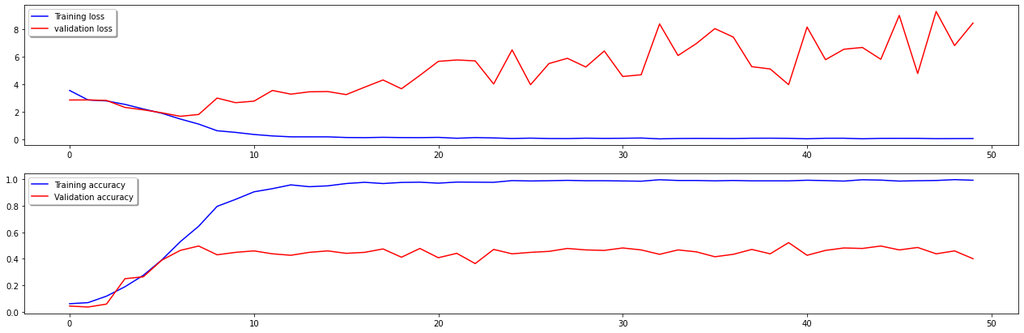

```python
cnn_loss, cnn_accuracy = cnn.evaluate(X_test, y_test_NN, verbose=1)
print('Test loss:', cnn_loss)
print('Test accuracy:', cnn_accuracy)


fig, ax = plt.subplots(2,1 , figsize=(22,7))
ax[0].plot(history.history['loss'], color='b', label="Training loss")
ax[0].plot(history.history['val_loss'], color='r', label="validation loss",axes =ax[0])
legend = ax[0].legend(loc='best', shadow=True)

ax[1].plot(history.history['acc'], color='b', label="Training accuracy")
ax[1].plot(history.history['val_acc'], color='r',label="Validation accuracy")
legend = ax[1].legend(loc='best', shadow=True)
```

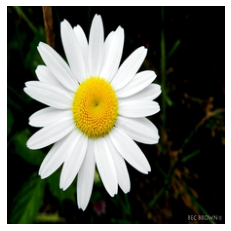

```
Predicted Label of the above image is :  15
```

```python
import matplotlib.image as mpimg
from tensorflow.keras.preprocessing import image
def imagepredict(path):
    img=mpimg.imread(path)
    plt.imshow(img)
    plt.axis('off')
    plt.show()

    # prediction
    img = image.load_img(path, target_size=(224, 224))
    x = image.img_to_array(img)
    x = np.expand_dims(x, axis=0)
    x = x.astype('float32')/255
    pred = np.argmax(cnn.predict(x))
    print("Predicted Label of the above image is : ",pred)

imagepredict("Prediction.jpg")
```